# IODS course project

Jonne Lintunen

## About the project (week 1)

I am **extremely excited** about this course and I am hoping to learn as much as I can from *data science* and *using R-language*. I am a PhD student in medicine at the University of Eastern Finland and I got the info about this course through our email list. For my PhD project I have been trying to learn the basics of Python (which I really love) but since this course seemed to be really interesting (eventhough it is using R instead of Python) I decided to jump in and try a new language.

#### Links to my GitHub repository and course diary

[My IODS repository](https://github.com/jonnelintunen/IODS-project)

[My IODS course diary](https://jonnelintunen.github.io/IODS-project/)

## Regression and model validation (week 2)

Dataset is read from the local folder:

```r
getwd()
```

```
## [1] "/Users/jonnelintunen/Desktop/IODS-project"
```

```r
setwd("/Users/jonnelintunen/Desktop/IODS-project/data")
table1 <- read.table("learning2014.txt")
head(table1)
```

```
##   gender age attitude     deep  stra     surf points
## 1      F  53       37 3.583333 3.375 2.583333     25
## 2      M  55       31 2.916667 2.750 3.166667     12
## 3      F  49       25 3.500000 3.625 2.250000     24
## 4      M  53       35 3.500000 3.125 2.250000     10
## 5      M  49       37 3.666667 3.625 2.833333     22
## 6      F  38       38 4.750000 3.625 2.416667     21
```

Dataset has 166 observations (= individuals) and 7 variables (**gender**, **age**, global **attitude** towards statistics, means of the questions relating to **deep**, **strategic** and **surface** learning and total **points** of the survey).

### Overview of the dataset

```r
library(ggplot2)
library(plyr)
```

**Gender variable**

```r
gender_F <- subset(table1, gender == "F")
nrow(gender_F)
```

```
## [1] 110
```

```r
gender_M <- subset(table1, gender == "M")
nrow(gender_M)
```

```
## [1] 56
```

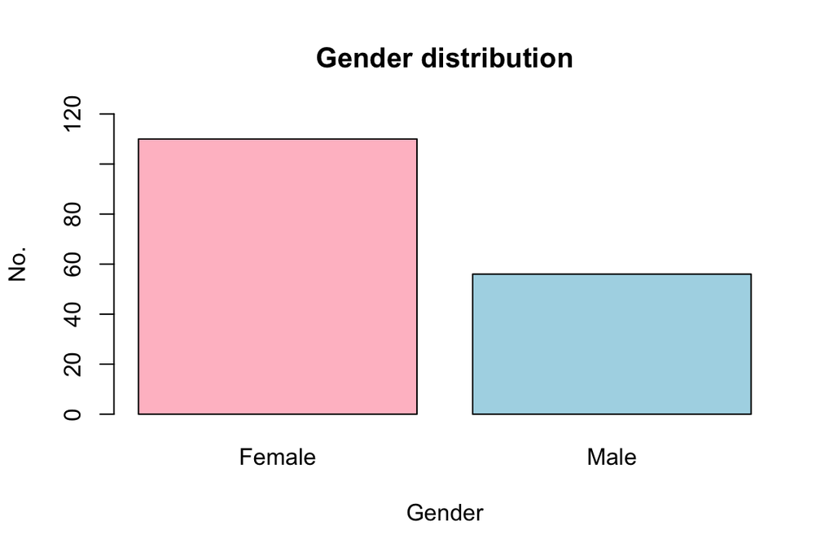

```r
gender_counter <- count(table1, "gender")
barplot(gender_counter$freq, main = "Gender distribution", xlab = "Gender", ylab = "No.", col = c("pink", "lightblue"), names.arg = c("Female", "Male"), ylim = c(0, 120))
```

There are 110 females and 56 males in this dataset.

**Age variable**

```r
age_all <- table1$age
mean(age_all)
```

```
## [1] 25.51205
```

Mean age of the dataset is 25.51 years.

```r
age_F <- subset(table1, gender == "F")
mean(age_F$age)
```

```
## [1] 24.85455
```

```r
min(age_F$age)
```

```
## [1] 17
```

```r
max(age_F$age)
```

```
## [1] 53
```

Mean age of females is 24.85 years; the youngest is 17 years and the oldest 53 years.

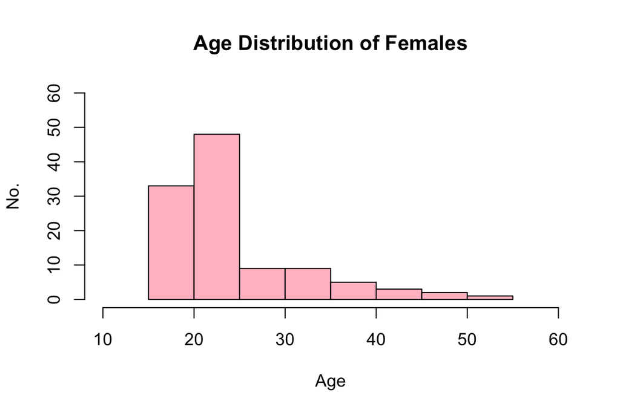

```r
hist(age_F$age, main = "Age Distribution of Females", xlab = "Age", ylab = "No.", ylim = c(0, 60), xlim = c(10, 60), col = "pink")
```

```r
age_M <- subset(table1, gender == "M")
mean(age_M$age)
```

```
## [1] 26.80357
```

```r
min(age_M$age)
```

```
## [1] 19
```

```r
max(age_M$age)
```

```
## [1] 55
```

Mean age of males is 26.80 years; the youngest is 19 years and the oldest is 55 years.

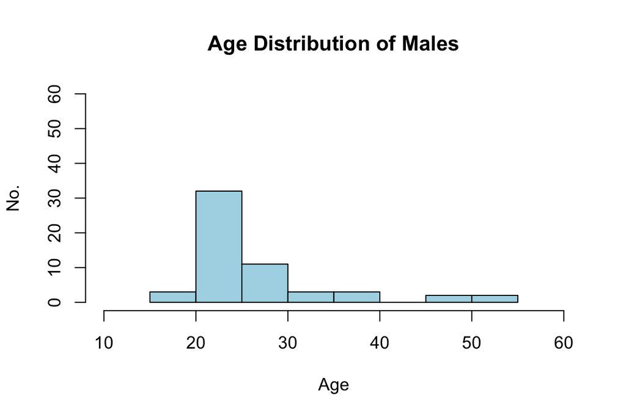

```r
hist(age_M$age, main = "Age Distribution of Males", xlab = "Age", ylab = "No.", ylim = c(0, 60), xlim = c(10, 60), col = "lightblue")
```

### Regression model

```r
library(GGally)
```

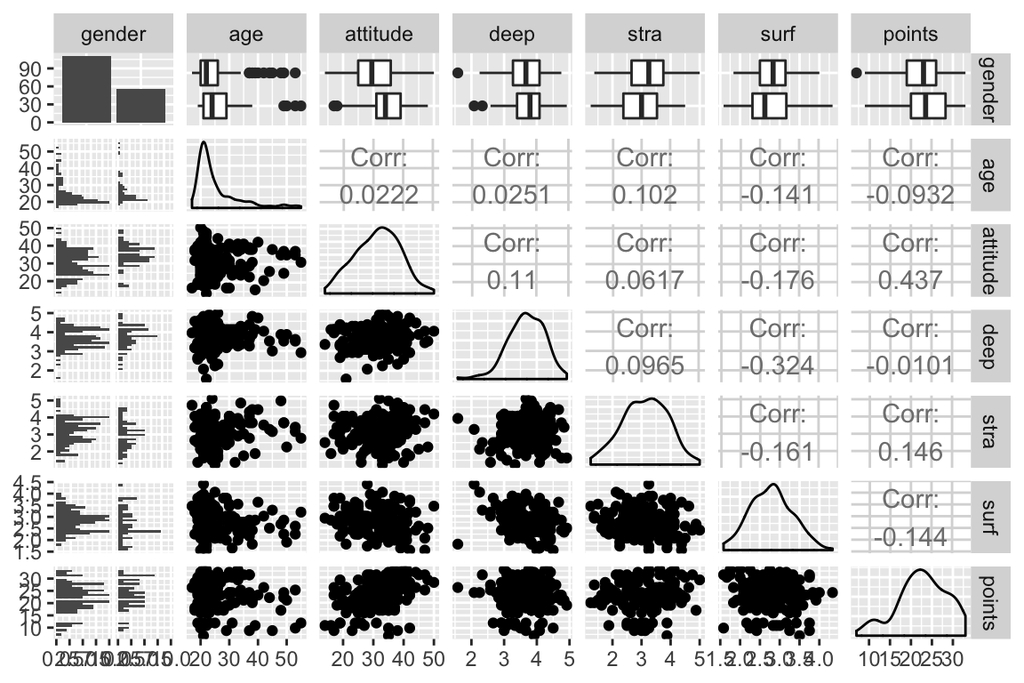

```r
ggpairs(table1)
```

```r
my_model <- lm(points ~ attitude  + stra + deep, data = table1)
summary(my_model)
```

```
##
## Call:
## lm(formula = points ~ attitude + stra + deep, data = table1)
##
## Residuals:
##      Min       1Q   Median       3Q      Max
## -17.5239  -3.4276   0.5474   3.8220  11.5112
##
## Coefficients:
##             Estimate Std. Error t value Pr(>|t|)
## (Intercept) 11.39145    3.40775   3.343  0.00103 **
## attitude     0.35254    0.05683   6.203 4.44e-09 ***
## stra         0.96208    0.53668   1.793  0.07489 .
## deep        -0.74920    0.75066  -0.998  0.31974
## ---
## Signif. codes:  0 '***' 0.001 '**' 0.01 '*' 0.05 '.' 0.1 ' ' 1
##
## Residual standard error: 5.289 on 162 degrees of freedom
## Multiple R-squared:  0.2097, Adjusted R-squared:  0.195
## F-statistic: 14.33 on 3 and 162 DF,  p-value: 2.521e-08
```

From the summary table we can see that P-values for attitude is statistically significant and stra and deep variables’ P-values are not. Therefore variables stra and deep are excluded.

```r
my_model <- lm(points ~ attitude, data = table1)
summary(my_model)
```

```
##
## Call:
## lm(formula = points ~ attitude, data = table1)
##
## Residuals:
##      Min       1Q   Median       3Q      Max
## -16.9763  -3.2119   0.4339   4.1534  10.6645
##
## Coefficients:
##             Estimate Std. Error t value Pr(>|t|)
## (Intercept) 11.63715    1.83035   6.358 1.95e-09 ***
## attitude     0.35255    0.05674   6.214 4.12e-09 ***
## ---
## Signif. codes:  0 '***' 0.001 '**' 0.01 '*' 0.05 '.' 0.1 ' ' 1
##
## Residual standard error: 5.32 on 164 degrees of freedom
## Multiple R-squared:  0.1906, Adjusted R-squared:  0.1856
## F-statistic: 38.61 on 1 and 164 DF,  p-value: 4.119e-09
```

Now P-value is 4.12e-09 (<< 0.05). **Residuals** are the difference between actual values and values that the model predicted. Residuals should be distributed symmetrically on the both sides of zero and the mean line should be quite horizontal.

From the Coefficients part of the summary we can see that **Intercept Estimate** is 11.63715. That means that the average of the predicted target variable (points) in our dataset is 11.63715 when explanatory variables are zero. The next row is our explanatory variable attitude. The **coefficient estimate** for attitude is 0.35255 and it tells us that when attitude increases one unit, the points will increase by 0.35255 units. **Standard error** for this is 0.05674 and it tells us that the coefficient estimate can vary by 0.05674 units. The **t-value** is used to decide whether to reject null hypothesis or not. It measures how many standard deviation units is the coefficient estimate from zero. If the t-value is small we cannot reject null hypothesis. The **PR(>|t|)** is the propability of finding any observation larger than the t-value. Small P-value indicates that there is a real association between the explanatory variables and the target variable and the coefficient estimate is not due to chance.The **residual standard error** tells how much on average do predicted values deviate from the regression line. Degrees of freedom is basically the number of observations that was used to calculate the residual standard error. The **multiple R-squared** is always between 0 and 1 and it measures how well explanatory variables explain the target variable. In this model R-squred is 0.1906 and it means that 19 % of the changes in the target variable (points) can be explained by the explanatory variables (attitude). **Adjusted R-square** adjusts the R-square when multiple explanatory variables are used (otherwise R-square would always increase when more variables are used). The **F-statistic** measures the association between explanatory variables and target variable. The larger the F-statistic is the better but it should always be larger than 1 to make the results statistically significant.

In conclusion in this model residuals are symmetrically distributed, t-value for coefficient estimate (attitude) is over 6 (> 0) and P-value for coefficient estimate is 4.12e-09 (<<< 0.05). F-statistic is 38.61 (> 1) and P-value for that is 4.119e-09. So all in all we can reject null hypothesis (“There is no association between attitude towards statistics and total points of the query.”).

### Diagnostic plots

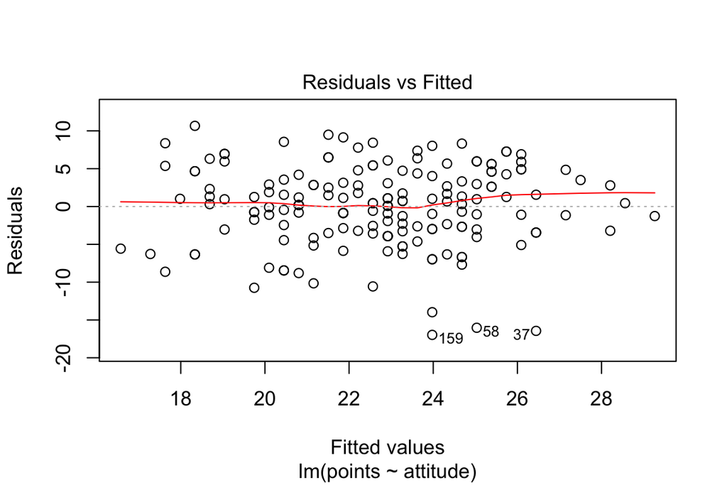

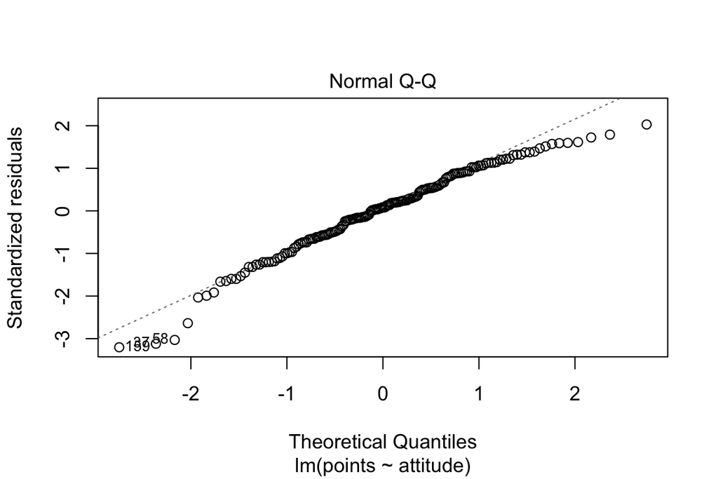

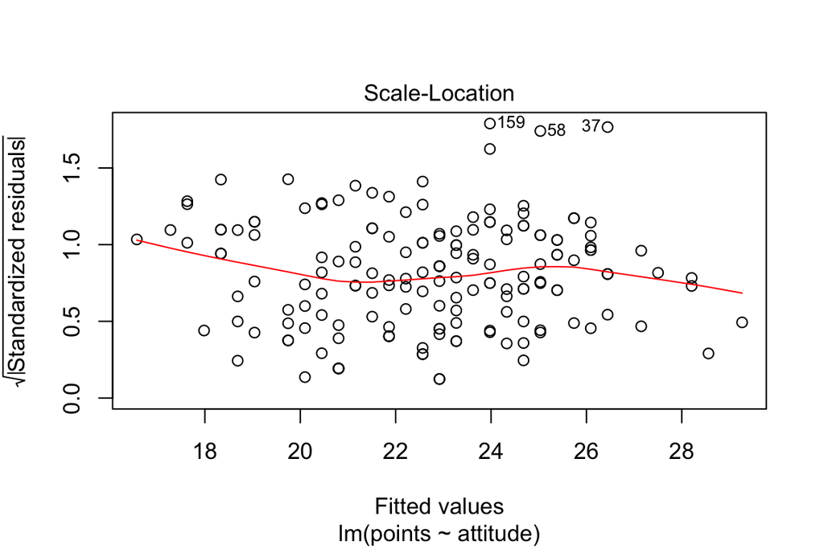

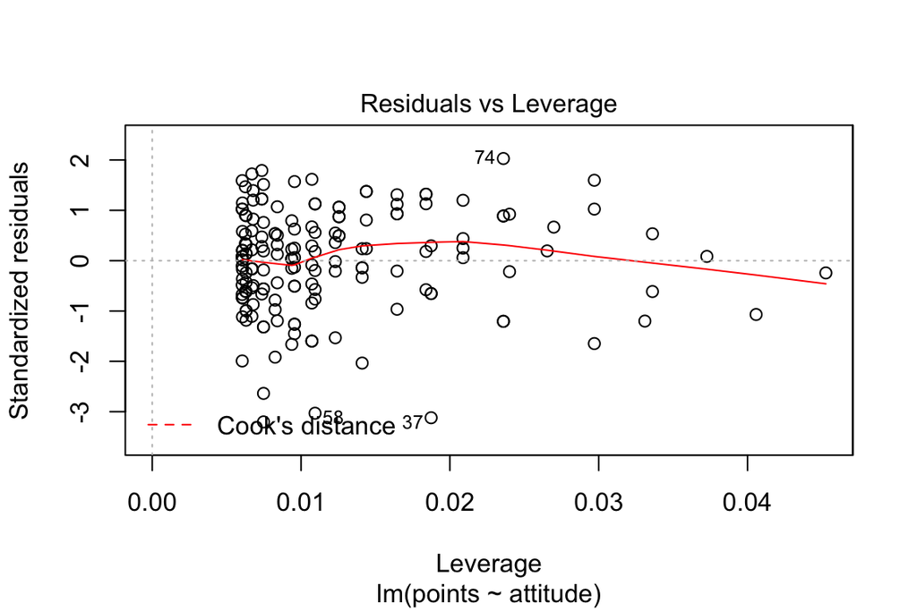

```r
plot(my_model)
```

**Residual vs Fitted plot** shows a horizontal line which means that residuals are symmetrically distributed. **Normal Q-Q plot** has a quite straight line so residuals are normally distributed and not skewed. **Scale location plot** shows a horizontal line meaning that residuals are spread equally. There are no outliers on the **Residuals vs Leverage plot** so there are no “influential” cases meaning that there are no residuals that could skew the results alone.

## Logistic regression (week 3)

Dataset is read from a local folder

```r
getwd()
```

```
## [1] "/Users/jonnelintunen/Desktop/IODS-project"
```

```r
setwd("/Users/jonnelintunen/Desktop/IODS-project/data")
alc <- read.table("alc.txt", header = T)
head(alc)
```

```
##   school sex age address famsize Pstatus Medu Fedu     Mjob     Fjob
## 1     GP   F  18       U     GT3       A    4    4  at_home  teacher
## 2     GP   F  17       U     GT3       T    1    1  at_home    other
## 3     GP   F  15       U     LE3       T    1    1  at_home    other
## 4     GP   F  15       U     GT3       T    4    2   health services
## 5     GP   F  16       U     GT3       T    3    3    other    other
## 6     GP   M  16       U     LE3       T    4    3 services    other
##       reason nursery internet guardian traveltime studytime failures
## 1     course     yes       no   mother          2         2        0
## 2     course      no      yes   father          1         2        0
## 3      other     yes      yes   mother          1         2        2
## 4       home     yes      yes   mother          1         3        0
## 5       home     yes       no   father          1         2        0
## 6 reputation     yes      yes   mother          1         2        0
##   schoolsup famsup paid activities higher romantic famrel freetime goout
## 1       yes     no   no         no    yes       no      4        3     4
## 2        no    yes   no         no    yes       no      5        3     3
## 3       yes     no  yes         no    yes       no      4        3     2
## 4        no    yes  yes        yes    yes      yes      3        2     2
## 5        no    yes  yes         no    yes       no      4        3     2
## 6        no    yes  yes        yes    yes       no      5        4     2
##   Dalc Walc health absences G1 G2 G3 alc_use high_use
## 1    1    1      3        5  2  8  8     1.0    FALSE
## 2    1    1      3        3  7  8  8     1.0    FALSE
## 3    2    3      3        8 10 10 11     2.5     TRUE
## 4    1    1      5        1 14 14 14     1.0    FALSE
## 5    1    2      5        2  8 12 12     1.5    FALSE
## 6    1    2      5        8 14 14 14     1.5    FALSE
```

```r
tail(alc)
```

```
##     school sex age address famsize Pstatus Medu Fedu     Mjob     Fjob
## 377     MS   F  19       R     GT3       T    2    3 services    other
## 378     MS   F  18       U     LE3       T    3    1  teacher services
## 379     MS   F  18       U     GT3       T    1    1    other    other
## 380     MS   F  18       U     GT3       T    1    1    other    other
## 381     MS   M  17       U     LE3       T    3    1 services services
## 382     MS   M  18       R     LE3       T    3    2 services    other
##     reason nursery internet guardian traveltime studytime failures
## 377 course      no      yes   mother          1         3        1
## 378 course     yes      yes   mother          1         2        0
## 379 course     yes       no   mother          2         2        2
## 380 course     yes       no   mother          2         2        0
## 381 course      no      yes   mother          2         1        0
## 382 course      no      yes   mother          3         1        0
##     schoolsup famsup paid activities higher romantic famrel freetime goout
## 377        no     no   no        yes    yes       no      5        4     2
## 378        no    yes  yes         no    yes       no      4        3     4
## 379        no     no   no        yes    yes       no      2        2     2
## 380        no     no   no        yes    yes       no      1        1     1
## 381        no     no   no         no    yes       no      2        4     5
## 382        no     no   no         no    yes       no      4        4     1
##     Dalc Walc health absences G1 G2 G3 alc_use high_use
## 377    1    2      5        2  8  8  5     1.5    FALSE
## 378    1    1      1        2 11 12 12     1.0    FALSE
## 379    2    2      5        2  6  6  4     2.0    FALSE
## 380    1    1      5        3  8  8  4     1.0    FALSE
## 381    3    4      2        4 12 13 13     3.5     TRUE
## 382    3    4      5        2 10 12 10     3.5     TRUE
```

### Selecting variables and hypothesis

- High alcohol users use less time for studying
- High alc users have more failures
- High alc users are more usually men
- High alc users have more absences

### Logistic regression

```r
logistic_model <- glm(high_use ~ studytime + failures + sex + absences, data = alc, family = "binomial")
summary(logistic_model)
```

```
##
## Call:
## glm(formula = high_use ~ studytime + failures + sex + absences,
##     family = "binomial", data = alc)
##
## Deviance Residuals:
##     Min       1Q   Median       3Q      Max
## -2.1213  -0.8226  -0.6017   1.0824   2.1185
##
## Coefficients:
##             Estimate Std. Error z value Pr(>|z|)
## (Intercept) -1.11174    0.43028  -2.584 0.009773 **
## studytime   -0.34003    0.16259  -2.091 0.036499 *
## failures     0.36048    0.19472   1.851 0.064126 .
## sexM         0.79470    0.25212   3.152 0.001621 **
## absences     0.08734    0.02296   3.803 0.000143 ***
## ---
## Signif. codes:  0 '***' 0.001 '**' 0.01 '*' 0.05 '.' 0.1 ' ' 1
##
## (Dispersion parameter for binomial family taken to be 1)
##
##     Null deviance: 465.68  on 381  degrees of freedom
## Residual deviance: 419.82  on 377  degrees of freedom
## AIC: 429.82
##
## Number of Fisher Scoring iterations: 4
```

studytime, sex and absences are statistically significant (z-value over 2 which corresponds approx to P-value < 0.05). The bigger the z-value is the better: z-value is Coefficient Estimate divided by Standard Error, so if z-value is big it means that Standard Error is small.

```r
coef(logistic_model)
```

```
## (Intercept)   studytime    failures        sexM    absences
## -1.11173770 -0.34003347  0.36048380  0.79469663  0.08734126
```

### Odds ratio

```r
library(dplyr)
OR <- coef(logistic_model) %>% exp
CI <- confint(logistic_model) %>% exp
cbind(OR, CI)
```

```
##                    OR     2.5 %    97.5 %
## (Intercept) 0.3289868 0.1402796 0.7609560
## studytime   0.7117465 0.5129770 0.9721184
## failures    1.4340230 0.9804979 2.1153252
## sexM        2.2137693 1.3559547 3.6508476
## absences    1.0912690 1.0455005 1.1442053
```

And again, studytime, sex and absences are statistically significant because CI doesn’t include one. Results for significant variables:

- When studytime increases by one unit, alcohol consumption is 0.71 (0.51-0.97) times lower
- Being male increases the odds of being high alc user by 2.21 times (1.36-3.65) compared to females
- When absences increase by one unit, alcohol consumption is 1.09 (1.05-1.14) times higher

### Binary predictions

```r
new_model <- glm(high_use ~ studytime + sex + absences, data = alc, family = "binomial")
prob <- predict(new_model, type = "response")
alc <- mutate(alc, probability = prob)
alc <- mutate(alc, prediction = prob > 0.5)

table(high_use = alc$high_use, prediction = alc$prediction)
```

```
##         prediction
## high_use FALSE TRUE
##    FALSE   258   10
##    TRUE     88   26
```

Model predicts 10 + 88 = 98 (26 %) cases wrongly from the total of 382 cases.

## Clustering and classification (week 4)

Dataset is read from MASS package inside R

```r
library(MASS)
data("Boston")
str(Boston)
```

```
## 'data.frame':    506 obs. of  14 variables:
##  $ crim   : num  0.00632 0.02731 0.02729 0.03237 0.06905 ...
##  $ zn     : num  18 0 0 0 0 0 12.5 12.5 12.5 12.5 ...
##  $ indus  : num  2.31 7.07 7.07 2.18 2.18 2.18 7.87 7.87 7.87 7.87 ...
##  $ chas   : int  0 0 0 0 0 0 0 0 0 0 ...
##  $ nox    : num  0.538 0.469 0.469 0.458 0.458 0.458 0.524 0.524 0.524 0.524 ...
##  $ rm     : num  6.58 6.42 7.18 7 7.15 ...
##  $ age    : num  65.2 78.9 61.1 45.8 54.2 58.7 66.6 96.1 100 85.9 ...
##  $ dis    : num  4.09 4.97 4.97 6.06 6.06 ...
##  $ rad    : int  1 2 2 3 3 3 5 5 5 5 ...
##  $ tax    : num  296 242 242 222 222 222 311 311 311 311 ...
##  $ ptratio: num  15.3 17.8 17.8 18.7 18.7 18.7 15.2 15.2 15.2 15.2 ...
##  $ black  : num  397 397 393 395 397 ...
##  $ lstat  : num  4.98 9.14 4.03 2.94 5.33 ...
##  $ medv   : num  24 21.6 34.7 33.4 36.2 28.7 22.9 27.1 16.5 18.9 ...
```

```r
summary(Boston)
```

```
##       crim                zn             indus            chas
##  Min.   : 0.00632   Min.   :  0.00   Min.   : 0.46   Min.   :0.00000
##  1st Qu.: 0.08204   1st Qu.:  0.00   1st Qu.: 5.19   1st Qu.:0.00000
##  Median : 0.25651   Median :  0.00   Median : 9.69   Median :0.00000
##  Mean   : 3.61352   Mean   : 11.36   Mean   :11.14   Mean   :0.06917
##  3rd Qu.: 3.67708   3rd Qu.: 12.50   3rd Qu.:18.10   3rd Qu.:0.00000
##  Max.   :88.97620   Max.   :100.00   Max.   :27.74   Max.   :1.00000
##       nox               rm             age              dis
##  Min.   :0.3850   Min.   :3.561   Min.   :  2.90   Min.   : 1.130
##  1st Qu.:0.4490   1st Qu.:5.886   1st Qu.: 45.02   1st Qu.: 2.100
##  Median :0.5380   Median :6.208   Median : 77.50   Median : 3.207
##  Mean   :0.5547   Mean   :6.285   Mean   : 68.57   Mean   : 3.795
##  3rd Qu.:0.6240   3rd Qu.:6.623   3rd Qu.: 94.08   3rd Qu.: 5.188
##  Max.   :0.8710   Max.   :8.780   Max.   :100.00   Max.   :12.127
##       rad              tax           ptratio          black
##  Min.   : 1.000   Min.   :187.0   Min.   :12.60   Min.   :  0.32
##  1st Qu.: 4.000   1st Qu.:279.0   1st Qu.:17.40   1st Qu.:375.38
##  Median : 5.000   Median :330.0   Median :19.05   Median :391.44
##  Mean   : 9.549   Mean   :408.2   Mean   :18.46   Mean   :356.67
##  3rd Qu.:24.000   3rd Qu.:666.0   3rd Qu.:20.20   3rd Qu.:396.23
##  Max.   :24.000   Max.   :711.0   Max.   :22.00   Max.   :396.90
##      lstat            medv
##  Min.   : 1.73   Min.   : 5.00
##  1st Qu.: 6.95   1st Qu.:17.02
##  Median :11.36   Median :21.20
##  Mean   :12.65   Mean   :22.53
##  3rd Qu.:16.95   3rd Qu.:25.00
##  Max.   :37.97   Max.   :50.00
```

The Boston dataset has 506 observations and 14 variables. Dataset is for analyzing housing values in suburbs of Boston. Variables are

1. crim = per capita crime rate by town.
2. zn = proportion of residential land zoned for lots over 25,000 sq.ft.
3. indus = proportion of non-retail business acres per town.
4. chas = Charles River dummy variable (= 1 if tract bounds river; 0 otherwise).
5. nox = nitrogen oxides concentration (parts per 10 million).
6. rm = average number of rooms per dwelling.
7. age = proportion of owner-occupied units built prior to 1940.
8. dis = weighted mean of distances to five Boston employment centres.
9. rad = index of accessibility to radial highways.
10. tax = full-value property-tax rate per $10,000.
11. ptratio = pupil-teacher ratio by town.
12. black = 1000(Bk - 0.63)^2 where Bk is the proportion of blacks by town.
13. lstat = lower status of the population (percent).
14. medv = median value of owner-occupied homes in $1000s.

### Correlation between variables

```r
library(corrplot)
correlation_Boston <- cor(Boston)
correlation_Boston
```

```
##                crim          zn       indus         chas         nox
## crim     1.00000000 -0.20046922  0.40658341 -0.055891582  0.42097171
## zn      -0.20046922  1.00000000 -0.53382819 -0.042696719 -0.51660371
## indus    0.40658341 -0.53382819  1.00000000  0.062938027  0.76365145
## chas    -0.05589158 -0.04269672  0.06293803  1.000000000  0.09120281
## nox      0.42097171 -0.51660371  0.76365145  0.091202807  1.00000000
## rm      -0.21924670  0.31199059 -0.39167585  0.091251225 -0.30218819
## age      0.35273425 -0.56953734  0.64477851  0.086517774  0.73147010
## dis     -0.37967009  0.66440822 -0.70802699 -0.099175780 -0.76923011
## rad      0.62550515 -0.31194783  0.59512927 -0.007368241  0.61144056
## tax      0.58276431 -0.31456332  0.72076018 -0.035586518  0.66802320
## ptratio  0.28994558 -0.39167855  0.38324756 -0.121515174  0.18893268
## black   -0.38506394  0.17552032 -0.35697654  0.048788485 -0.38005064
## lstat    0.45562148 -0.41299457  0.60379972 -0.053929298  0.59087892
## medv    -0.38830461  0.36044534 -0.48372516  0.175260177 -0.42732077
##                  rm         age         dis          rad         tax
## crim    -0.21924670  0.35273425 -0.37967009  0.625505145  0.58276431
## zn       0.31199059 -0.56953734  0.66440822 -0.311947826 -0.31456332
## indus   -0.39167585  0.64477851 -0.70802699  0.595129275  0.72076018
## chas     0.09125123  0.08651777 -0.09917578 -0.007368241 -0.03558652
## nox     -0.30218819  0.73147010 -0.76923011  0.611440563  0.66802320
## rm       1.00000000 -0.24026493  0.20524621 -0.209846668 -0.29204783
## age     -0.24026493  1.00000000 -0.74788054  0.456022452  0.50645559
## dis      0.20524621 -0.74788054  1.00000000 -0.494587930 -0.53443158
## rad     -0.20984667  0.45602245 -0.49458793  1.000000000  0.91022819
## tax     -0.29204783  0.50645559 -0.53443158  0.910228189  1.00000000
## ptratio -0.35550149  0.26151501 -0.23247054  0.464741179  0.46085304
## black    0.12806864 -0.27353398  0.29151167 -0.444412816 -0.44180801
## lstat   -0.61380827  0.60233853 -0.49699583  0.488676335  0.54399341
## medv     0.69535995 -0.37695457  0.24992873 -0.381626231 -0.46853593
##            ptratio       black      lstat       medv
## crim     0.2899456 -0.38506394  0.4556215 -0.3883046
## zn      -0.3916785  0.17552032 -0.4129946  0.3604453
## indus    0.3832476 -0.35697654  0.6037997 -0.4837252
## chas    -0.1215152  0.04878848 -0.0539293  0.1752602
## nox      0.1889327 -0.38005064  0.5908789 -0.4273208
## rm      -0.3555015  0.12806864 -0.6138083  0.6953599
## age      0.2615150 -0.27353398  0.6023385 -0.3769546
## dis     -0.2324705  0.29151167 -0.4969958  0.2499287
## rad      0.4647412 -0.44441282  0.4886763 -0.3816262
## tax      0.4608530 -0.44180801  0.5439934 -0.4685359
## ptratio  1.0000000 -0.17738330  0.3740443 -0.5077867
## black   -0.1773833  1.00000000 -0.3660869  0.3334608
## lstat    0.3740443 -0.36608690  1.0000000 -0.7376627
## medv    -0.5077867  0.33346082 -0.7376627  1.0000000
```

```r
correlation_Boston <- round(correlation_Boston, digits = 2)
correlation_Boston
```

```
##          crim    zn indus  chas   nox    rm   age   dis   rad   tax
## crim     1.00 -0.20  0.41 -0.06  0.42 -0.22  0.35 -0.38  0.63  0.58
## zn      -0.20  1.00 -0.53 -0.04 -0.52  0.31 -0.57  0.66 -0.31 -0.31
## indus    0.41 -0.53  1.00  0.06  0.76 -0.39  0.64 -0.71  0.60  0.72
## chas    -0.06 -0.04  0.06  1.00  0.09  0.09  0.09 -0.10 -0.01 -0.04
## nox      0.42 -0.52  0.76  0.09  1.00 -0.30  0.73 -0.77  0.61  0.67
## rm      -0.22  0.31 -0.39  0.09 -0.30  1.00 -0.24  0.21 -0.21 -0.29
## age      0.35 -0.57  0.64  0.09  0.73 -0.24  1.00 -0.75  0.46  0.51
## dis     -0.38  0.66 -0.71 -0.10 -0.77  0.21 -0.75  1.00 -0.49 -0.53
## rad      0.63 -0.31  0.60 -0.01  0.61 -0.21  0.46 -0.49  1.00  0.91
## tax      0.58 -0.31  0.72 -0.04  0.67 -0.29  0.51 -0.53  0.91  1.00
## ptratio  0.29 -0.39  0.38 -0.12  0.19 -0.36  0.26 -0.23  0.46  0.46
## black   -0.39  0.18 -0.36  0.05 -0.38  0.13 -0.27  0.29 -0.44 -0.44
## lstat    0.46 -0.41  0.60 -0.05  0.59 -0.61  0.60 -0.50  0.49  0.54
## medv    -0.39  0.36 -0.48  0.18 -0.43  0.70 -0.38  0.25 -0.38 -0.47
##         ptratio black lstat  medv
## crim       0.29 -0.39  0.46 -0.39
## zn        -0.39  0.18 -0.41  0.36
## indus      0.38 -0.36  0.60 -0.48
## chas      -0.12  0.05 -0.05  0.18
## nox        0.19 -0.38  0.59 -0.43
## rm        -0.36  0.13 -0.61  0.70
## age        0.26 -0.27  0.60 -0.38
## dis       -0.23  0.29 -0.50  0.25
## rad        0.46 -0.44  0.49 -0.38
## tax        0.46 -0.44  0.54 -0.47
## ptratio    1.00 -0.18  0.37 -0.51
## black     -0.18  1.00 -0.37  0.33
## lstat      0.37 -0.37  1.00 -0.74
## medv      -0.51  0.33 -0.74  1.00
```

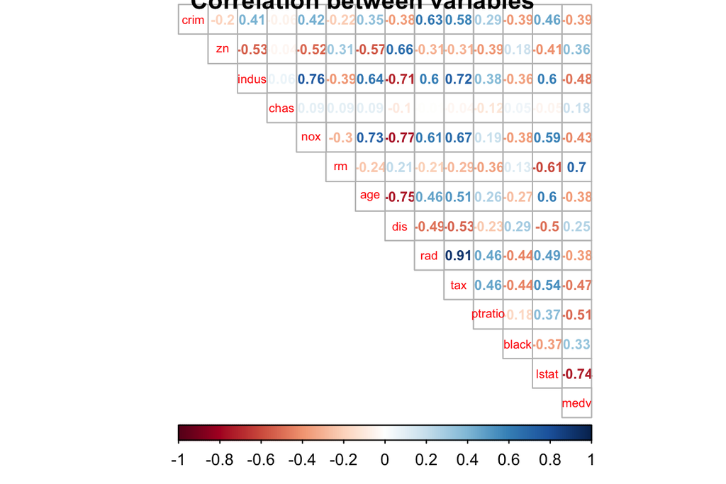

```r
corrplot(correlation_Boston, method = "number", type = "upper", cl.pos = "b", tl.pos = "d", tl.cex = 0.6, cl.cex = 0.8, number.cex = 0.7 , title = "Correlation between variables")
```

### Scaling the dataset and converting the scaled dataset to data frame

```r
scaled_Boston <- scale(Boston)
class(scaled_Boston)
```

```
## [1] "matrix"
```

```r
scaled_Boston <- as.data.frame(scaled_Boston)
```

### Creating categorical variable crime from the numerical variable crim

```r
bins <- quantile(scaled_Boston$crim)
bins
```

```
##           0%          25%          50%          75%         100%
## -0.419366929 -0.410563278 -0.390280295  0.007389247  9.924109610
```

```r
crime <- cut(scaled_Boston$crim, breaks = bins, include.lowest = TRUE, label = c("low", "med_low", "med_high", "high"))
table(crime)
```

```
## crime
##      low  med_low med_high     high
##      127      126      126      127
```

```r
scaled_Boston <- dplyr::select(scaled_Boston, -crim)
scaled_Boston <- data.frame(scaled_Boston, crime)
```

### Dividing the dataset for training and testing

```r
n <- nrow(scaled_Boston)

ind <- sample(n,  size = n * 0.8)

train <- scaled_Boston[ind, ]

test <- scaled_Boston[-ind, ]

correct_classes <- dplyr::select(test, crime)

test <- dplyr::select(test, -crime)
```

### Linear discriminant analysis (LDA)

Target variable is crime and all the other variables are explanatory variables.

```r
lda.crime <- lda(crime ~ ., data = train)
lda.crime
```

```
## Call:
## lda(crime ~ ., data = train)
##
## Prior probabilities of groups:
##       low   med_low  med_high      high
## 0.2549505 0.2623762 0.2475248 0.2351485
##
## Group means:
##                   zn      indus        chas        nox         rm
## low       0.86172448 -0.8892919 -0.08120770 -0.8540803  0.4508201
## med_low  -0.08860417 -0.3095150 -0.04947434 -0.5865633 -0.1223760
## med_high -0.37404455  0.2143070  0.12138096  0.4068509  0.1133129
## high     -0.48724019  1.0172655 -0.10655643  1.0365712 -0.3917124
##                 age        dis        rad        tax     ptratio
## low      -0.8560986  0.8301514 -0.6875068 -0.7699855 -0.40907758
## med_low  -0.3704160  0.3669406 -0.5484874 -0.4774234 -0.05528293
## med_high  0.3669811 -0.3895387 -0.3858168 -0.2774294 -0.29263258
## high      0.7976332 -0.8394051  1.6366336  1.5129868  0.77903654
##               black       lstat         medv
## low       0.3821805 -0.77894312  0.510313597
## med_low   0.3116826 -0.16642352  0.002177192
## med_high  0.0737957  0.02659783  0.195191188
## high     -0.8412963  0.89971732 -0.676662195
##
## Coefficients of linear discriminants:
##                 LD1         LD2          LD3
## zn       0.09968066  0.65943155 -0.968763879
## indus   -0.02169670 -0.26856352  0.233985979
## chas    -0.09688689 -0.03797115  0.036418328
## nox      0.41666502 -0.88306236 -1.366260536
## rm      -0.11774262 -0.10463281 -0.225556670
## age      0.24050812 -0.16861796 -0.008035937
## dis     -0.07213622 -0.26952362  0.166428699
## rad      2.94831919  1.05427313 -0.228538490
## tax      0.04233389 -0.12387696  0.705818707
## ptratio  0.12066580 -0.00831207 -0.304600220
## black   -0.13759215  0.01023636  0.116688381
## lstat    0.25340351 -0.29628342  0.378730667
## medv     0.23880451 -0.52744980 -0.121613065
##
## Proportion of trace:
##    LD1    LD2    LD3
## 0.9451 0.0398 0.0151
```

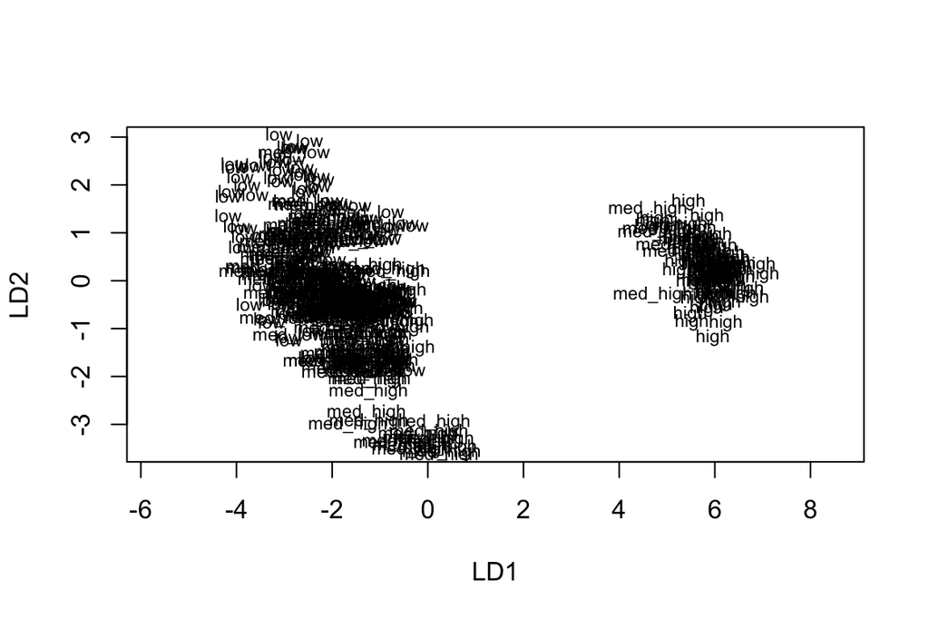

```r
plot(lda.crime, dimen = 2)
```

### Testing how well the model predicts values

```r
lda.pred <- predict(lda.crime, newdata = test)
lda.pred
```

[output not shown]

[output cut: 212 more lines]

```r
cross_tab <- table(correct = correct_classes$crime, predicted = lda.pred$class)
cross_tab
```

```
##           predicted
## correct    low med_low med_high high
##   low       17       6        1    0
##   med_low    4      12        4    0
##   med_high   0      12       14    0
##   high       0       0        0   32
```

```r
prop.table(cross_tab, 1)
```

```
##           predicted
## correct           low    med_low   med_high       high
##   low      0.70833333 0.25000000 0.04166667 0.00000000
##   med_low  0.20000000 0.60000000 0.20000000 0.00000000
##   med_high 0.00000000 0.46153846 0.53846154 0.00000000
##   high     0.00000000 0.00000000 0.00000000 1.00000000
```

From the cross tabulation’s percentage table we can see that the model predicts low and high classes well but there are more error with the classes that are “in the middle” (med_low, med_high).

### Clustering

First scaling the dataset

```r
library(MASS)
data("Boston")
str(Boston)
```

```
## 'data.frame':    506 obs. of  14 variables:
##  $ crim   : num  0.00632 0.02731 0.02729 0.03237 0.06905 ...
##  $ zn     : num  18 0 0 0 0 0 12.5 12.5 12.5 12.5 ...
##  $ indus  : num  2.31 7.07 7.07 2.18 2.18 2.18 7.87 7.87 7.87 7.87 ...
##  $ chas   : int  0 0 0 0 0 0 0 0 0 0 ...
##  $ nox    : num  0.538 0.469 0.469 0.458 0.458 0.458 0.524 0.524 0.524 0.524 ...
##  $ rm     : num  6.58 6.42 7.18 7 7.15 ...
##  $ age    : num  65.2 78.9 61.1 45.8 54.2 58.7 66.6 96.1 100 85.9 ...
##  $ dis    : num  4.09 4.97 4.97 6.06 6.06 ...
##  $ rad    : int  1 2 2 3 3 3 5 5 5 5 ...
##  $ tax    : num  296 242 242 222 222 222 311 311 311 311 ...
##  $ ptratio: num  15.3 17.8 17.8 18.7 18.7 18.7 15.2 15.2 15.2 15.2 ...
##  $ black  : num  397 397 393 395 397 ...
##  $ lstat  : num  4.98 9.14 4.03 2.94 5.33 ...
##  $ medv   : num  24 21.6 34.7 33.4 36.2 28.7 22.9 27.1 16.5 18.9 ...
```

```r
Boston <- scale(Boston)
str(Boston)
```

```
##  num [1:506, 1:14] -0.419 -0.417 -0.417 -0.416 -0.412 ...
##  - attr(*, "dimnames")=List of 2
##   ..$ : chr [1:506] "1" "2" "3" "4" ...
##   ..$ : chr [1:14] "crim" "zn" "indus" "chas" ...
##  - attr(*, "scaled:center")= Named num [1:14] 3.6135 11.3636 11.1368 0.0692 0.5547 ...
##   ..- attr(*, "names")= chr [1:14] "crim" "zn" "indus" "chas" ...
##  - attr(*, "scaled:scale")= Named num [1:14] 8.602 23.322 6.86 0.254 0.116 ...
##   ..- attr(*, "names")= chr [1:14] "crim" "zn" "indus" "chas" ...
```

```r
Boston <- as.data.frame(Boston)
str(Boston)
```

```
## 'data.frame':    506 obs. of  14 variables:
##  $ crim   : num  -0.419 -0.417 -0.417 -0.416 -0.412 ...
##  $ zn     : num  0.285 -0.487 -0.487 -0.487 -0.487 ...
##  $ indus  : num  -1.287 -0.593 -0.593 -1.306 -1.306 ...
##  $ chas   : num  -0.272 -0.272 -0.272 -0.272 -0.272 ...
##  $ nox    : num  -0.144 -0.74 -0.74 -0.834 -0.834 ...
##  $ rm     : num  0.413 0.194 1.281 1.015 1.227 ...
##  $ age    : num  -0.12 0.367 -0.266 -0.809 -0.511 ...
##  $ dis    : num  0.14 0.557 0.557 1.077 1.077 ...
##  $ rad    : num  -0.982 -0.867 -0.867 -0.752 -0.752 ...
##  $ tax    : num  -0.666 -0.986 -0.986 -1.105 -1.105 ...
##  $ ptratio: num  -1.458 -0.303 -0.303 0.113 0.113 ...
##  $ black  : num  0.441 0.441 0.396 0.416 0.441 ...
##  $ lstat  : num  -1.074 -0.492 -1.208 -1.36 -1.025 ...
##  $ medv   : num  0.16 -0.101 1.323 1.182 1.486 ...
```

Calculating the distances between the observations

```r
dist_eu <- dist(Boston)
summary(dist_eu)
```

```
##    Min. 1st Qu.  Median    Mean 3rd Qu.    Max.
##  0.1343  3.4625  4.8241  4.9111  6.1863 14.3970
```

[output not shown]

## Analysis of longitudinal data (week 6)

### BPRS dataset

```r
library(ggplot2)
getwd()
```

```
## [1] "/Users/jonnelintunen/Desktop/IODS-project"
```

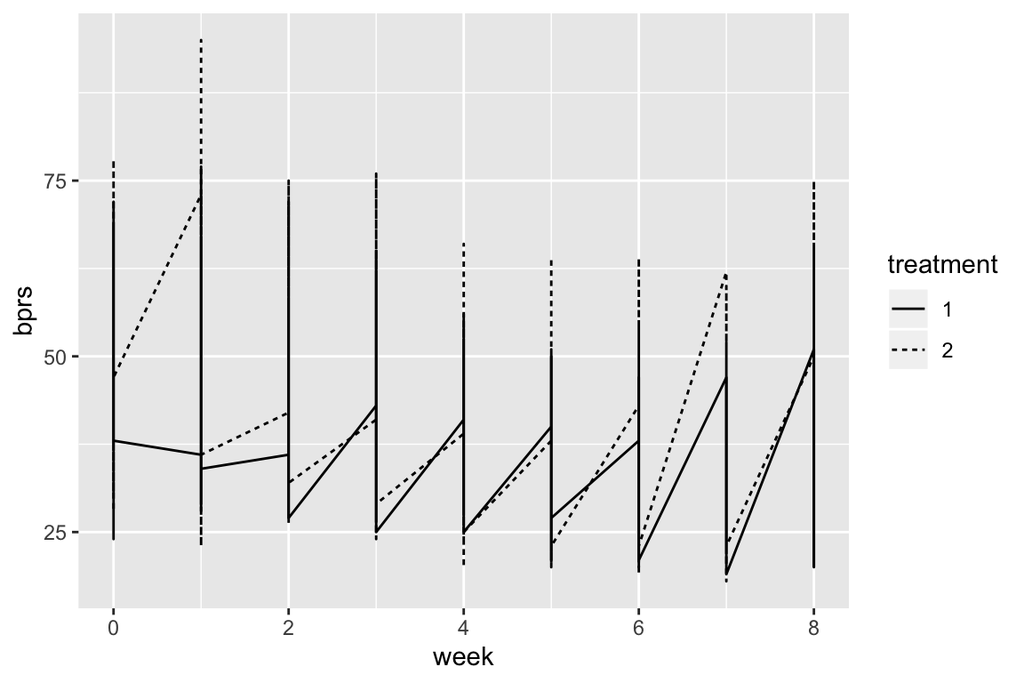

```r
setwd("/Users/jonnelintunen/Desktop/IODS-project/data")
BPRSlong <- read.table("BPRSlong.txt", header = T)
BPRSlong$treatment <- factor(BPRSlong$treatment)
BPRSlong$subject <- factor(BPRSlong$subject)
ggplot(BPRSlong, aes(x = week, y = bprs, group = treatment, linetype = treatment)) +
  geom_line()
```

### RATS dataset

```r
library(ggplot2)
getwd()
```

```
## [1] "/Users/jonnelintunen/Desktop/IODS-project"
```

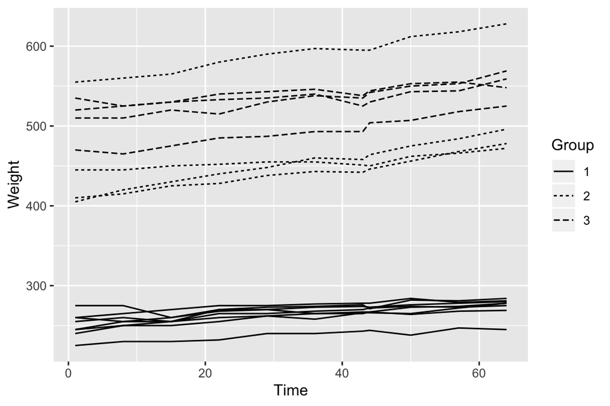

```r
setwd("/Users/jonnelintunen/Desktop/IODS-project/data")
RATSlong <- read.table("RATSlong.txt", header = T)
RATSlong$Group <- factor(RATSlong$Group)
ggplot(RATSlong, aes(x = Time, y = Weight, group = ID, linetype = Group)) +
  geom_line()
```

We can see that there is more increase in weight with the rats in the groups 2 and 3. In the group 1 the increase is rather insignificant.